# Introduction to R for criminologists: morning session

### US crime data

A quick demonstration using the data from the `crimedata` package shows us how we can map additional variables onto our visuals using aesthetics beyond the classic x and y. First, check you have installed and loaded the package, as outlined earlier in this exercise.

You can load in some open crime data using the `get_crime_data()` function from the package. Let’s just get the core data for 2017 for all the cities available. This might take a few moments on download.

```r
crimes <- get_crime_data(years = 2017, type = "core")
```

Take a look at the data using `View(crimes)` or use some of the basic exploratory functions we introduced at the beginning to get used to what the data looks like. You’ll notice that each row is a recorded crime, with associated information like the city in which the crime occurred, the offence type, and the census block in which the crime occurred. From this, we know the data is nested: crimes within census blocks, census blocks within cities.

First, let’s just subset the data by a crime type (disorderly conduct), and drop cases that are missing if we don’t know the location category, as we are going to use it later. We assign this new data frame to the object `dis_con`.

```r
dis_con <- crimes %>%
  filter(offense_type == "disorderly conduct") %>%
  drop_na(location_category)
```

We can now make a quick bar chart of crime counts for each city. Note how we don’t actually need to calculate these counts ourselves: if you don’t specify a y-axis variable in a bar plot, ggplot will just assume you want counts, which is a pretty common use for bar charts. We introduce some new options here: `coord_flip()` rotates the chart, `labs` allows you to change various different label names, and `theme_bw()` adds a pre-set [ggplot theme](http://www.sthda.com/english/wiki/ggplot2-themes-and-background-colors-the-3-elements) to the graph.

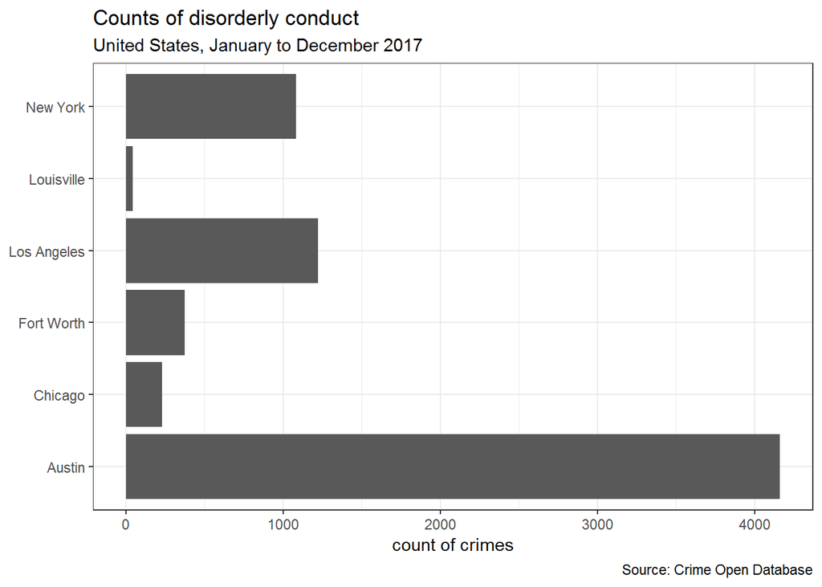

```r
ggplot(data = dis_con, mapping = aes(x = city_name)) + # set data and aesthetics
  geom_bar() +                                         # set geom
  labs(x = NULL,                                       # remove x-axis label
       y = "count of crimes",                          # optional labels
       title = "Counts of disorderly conduct",
       subtitle = "United States, January to December 2017",
       caption = "Source: Crime Open Database") +
  coord_flip() +                                       # flip the plot
  theme_bw()                                           # add a new theme
```

Let’s say we want to see how the location of disorderly conduct incidents varies by city. We can map the `location_category` variable (which now has no missings) using the `fill` aesthetic. Note the minor changes to the labels.

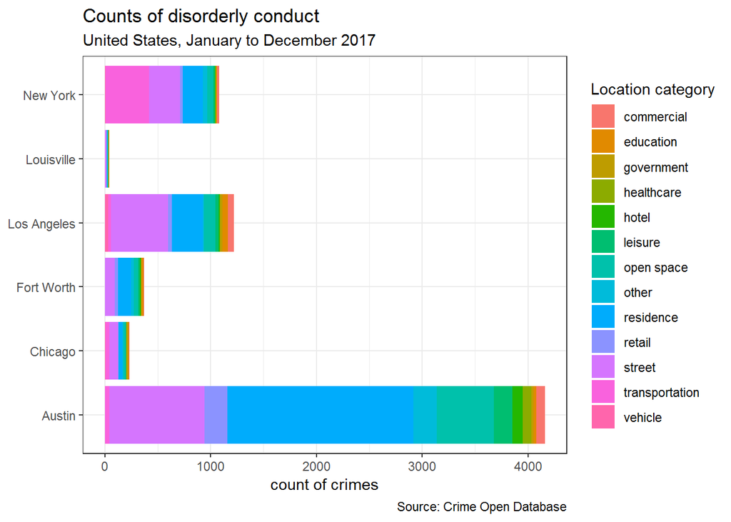

```r
ggplot(data = dis_con, mapping = aes(x = city_name, fill = location_category)) +
  geom_bar() +
  labs(x = NULL,
       y = "count of crimes",
       title = "Counts of disorderly conduct",
       subtitle = "United States, January to December 2017",
       caption = "Source: Crime Open Database",
       fill = "Location category") +  # new label for the fill aesthetic
  coord_flip() +
  theme_bw()
```

For the final example, we are going to combine it with a bit data wrangling. This introduces some new verbs: `group_by()` groups observations by whatever variables are specified. Any subsequent functions are performed on the groups rather than each observation. `tally` is just a way of summing the number of observations, in this case, by group. By way of example, the following will print out the number of observations (i.e. in this case, crimes) by each city.

```r
crimes %>%
  group_by(city_name) %>%
  tally(name = "crime_counts") # We specify the name of the new variable too.
```

```
## # A tibble: 13 x 2
##    city_name      crime_counts
##    <fct>                 <int>
##  1 Austin                87039
##  2 Boston                44677
##  3 Chicago              263536
##  4 Detroit               80074
##  5 Fort Worth            56283
##  6 Kansas City          118833
##  7 Los Angeles          243969
##  8 Louisville            41198
##  9 Mesa                  33258
## 10 New York             460685
## 11 San Francisco        112118
## 12 Tucson                79827
## 13 Virginia Beach        28843
```

For the next visualisation, however, we want to sum the number of crimes by census block for each city. So, we have to group by two variables, otherwise we lose the information about which census block is in which city. We also filter out outliers, which we’ve just decided are any counts greater than 20. This is arbitrary and just for the purposes of the demonstration!

```r
block_counts <- crimes %>%
  group_by(city_name, census_block) %>% # Group by city and census block
  tally(name = "crime_counts") %>%      # Counts (by city and census block)
  filter(crime_counts <= 20)            # Exclude counts greater than 20
```

Take a look at the data now with `View(block_counts)`. We now have a count of the number of crimes for each census block by city.

We can now plot these data to show how concentrated crime is in each city. Here, we make a density plot, but split the plot into [small multiples](https://www.dshkol.com/2017/small-multiples-with-maps/) by city using the `facet_wrap()` function. You’ll also notice that we also specify the fill as black, but not as an aesthetic. Aesthetics are mapped to variables! Here, we are not mapping `fill` to a variable, just stating that it should be black.

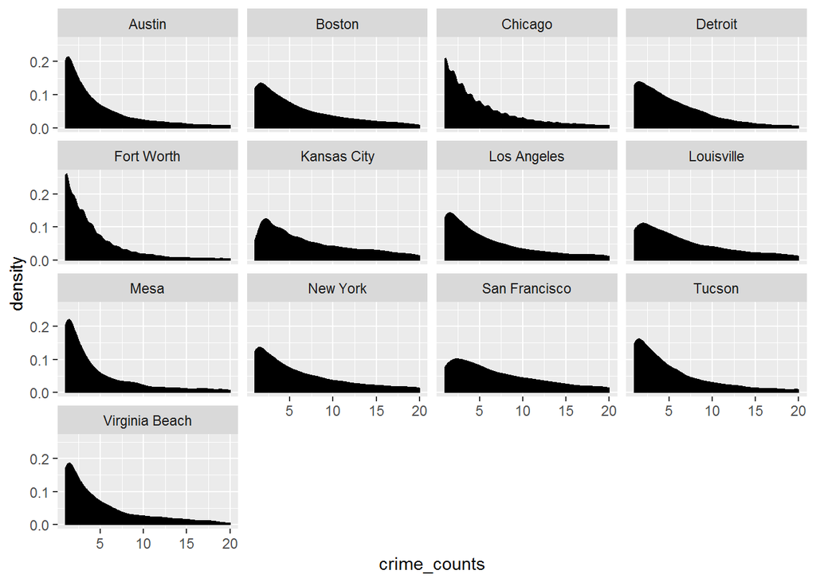

```r
ggplot(data = block_counts, mapping = aes(x = crime_counts)) +
  geom_density(fill = "black") +
  facet_wrap(~ city_name) +
  theme(legend.position = "none")  # remove the legend, since it only has one value
```

The possibilities are nearly endless with ggplot2 but we’ve introduced you to a few of the key concepts. The best way to get proficient at visualising using ggplot is to practice, ideally with your own data. Sketch out what you want to achieve, thinking about what structure the data will have to be in to achieve what you want, and which aesthetics are going to be meaningful to get your message across.

## Saving data frames

Just as R is capable of importing numerous different types of data (e.g. .csv, .dta, .sav amongst others), it can also save data in many formats. We will demonstrate how to save the `block_counts` data frame object, used above, as a .csv file using `write_csv()`. We’ll need to specify the data frame object we want to save, and the directory where we want to save the file, with the file name at the end. As with reading data, data you save will be saved within your project directory.

```r
write_csv(block_counts, path = "output_data/block_counts.csv")
```

## Saving visuals

So far, when we’ve created a graphic, we haven’t been assigning it to an object, so everything has just appeared in the plot window. If we want to save a graphic, we need to assign it to an object, and then use the `ggsave()` function. We’ve chosen a .jpeg but there many [other options](https://ggplot2.tidyverse.org/reference/ggsave.html). You can use the example below as a template.

```r
p1 <- ggplot(data = block_counts, mapping = aes(x = crime_counts)) +
        geom_density(fill = "black") +
        facet_wrap(~ city_name) +
        theme(legend.position = "none")

ggsave(filename = "output_files/my_plot.jpeg", plot = p1, device = "jpeg")
```

## Useful resources

1. **R for Data Science** This [free book](https://r4ds.had.co.nz/) gives you a comprehensive introduction to the tidyverse. The material in that book will allow you to do the vast majority of fundamental data tasks in R, including everything we’ve done in this tutorial. It is available quite cheaply as a paperback too.
2. **Google** This is probably your best resource! Queries will often take you to great websites like Stack Overflow, where in 99% of cases, someone has asked exactly the same question you have! To get an answer that uses the tidyverse, follow every Google search with the word ‘tidyverse’ or the specific package within the tidyverse (e.g. ggplot2) if you know which one it is.
3. **Twitter** To broaden your knowledge of R more generally, or to keep up-to-date with the latest developments, Twitter is a great resource. There are few key people, such as [Hadley Wickham](https://twitter.com/hadleywickham?ref_src=twsrc%5Egoogle%7Ctwcamp%5Eserp%7Ctwgr%5Eauthor), [Mara Averick](https://twitter.com/dataandme?ref_src=twsrc%5Egoogle%7Ctwcamp%5Eserp%7Ctwgr%5Eauthor), [Julia Silge](https://twitter.com/juliasilge?lang=en) and [Thomas Lin Pederson](https://twitter.com/thomasp85?lang=en), who are definitely worth following, but there are many others who you will come across. The hashtag [#rstats](https://twitter.com/search?q=%23rstats) also showcases great graphics and other work people have done with R.